# Vignette ecpc: simulation study

Mirrelijn van Nee

# Overview

This vignette can be used to reproduce the simulation results from [1].

Estimation and prediction performance have been compared for several methods in [2]. Here, we focus on continuous co-data to exemplify the newly proposed co-data models. First, we perform a simulation study to compare the estimates of the prior variance and prediction performance for different co-data models proposed here and the adaptive discretisation proposed in the first version of ecpc. Secondly, we perform a simulation study to compare different variable selection methods. Lastly, we perform a simulation study on computation time and peak memory costs of fitting various co-data models compared to a co-data agnostic ridge and lasso.

First, make sure the following libraries are installed:

```r
if(!requireNamespace("ggplot2")) install.packages("ggplot2")
if(!requireNamespace("ggpubr")) install.packages("ggpubr")
if(!requireNamespace("ecpc")) install.packages("ecpc")
if(!requireNamespace("squeezy")) install.packages("squeezy")
if(!requireNamespace("dplyr")) install.packages("dplyr")
if(!requireNamespace("RColorBrewer")) install.packages("RColorBrewer")
if(!requireNamespace("foreach")) install.packages("foreach")
if(!requireNamespace("doParallel")) install.packages("doParallel")
if(!requireNamespace("glmnet")) install.packages("glmnet")
if(!requireNamespace("mvtnorm")) install.packages("mvtnorm")
if(!requireNamespace("pROC")) install.packages("pROC")
if(!requireNamespace("devtools")) install.packages("devtools")
library(devtools)
if(!requireNamespace("fwelnet")) install_github("kjytay/fwelnet")
if(!requireNamespace("CoRF")) install_github("DennisBeest/CoRF")
if(!requireNamespace("ggh4x")) install_github("teunbrand/ggh4x")
```

The sections below on the three different simulation studies can be run independently from each other. Results are pre-saved and stored in the following folder:

```r
pathResults <- "./Results_sim_study/"
```

# Simulation study 1: Estimation and prediction performance of various co-data models

We use the same simulation set-up as in [2] and simulate $50$ training and test data sets for some true vector of regression coefficients $\mathbf{\beta}^0\in\mathbb{R}^{300}$. Again, we consider random and informative co-data, but now continuous versions of it:

- `Random`: generate standard normal co-data $Z_k\overset{i.i.d.}{\sim}N(0,1)$ for $k=1,..,p$.
- `Informative`: use the true regression coefficients to inform the co-data; $Z_k=|\beta^0_k|$.

## Run analysis

To rerun the analysis and generation of toy data, first set the following variables to `TRUE`:

```r
runLinear <- FALSE
runGAM <- FALSE
runSCAM <- FALSE
runSCAMpmi <- FALSE
runAD <- FALSE

generateData <- TRUE #set to true if not generated before
nSim <- 50 #set to lower number for quicker run
runParallel <- FALSE
```

### Load libraries

Load the libraries needed for the analysis. Use multiple cores if available and if `runParallel=TRUE`.

```r
library(ecpc)
library(dplyr) #for data wrangling results
```

```r
library(ggplot2) #for plotting results
library(RColorBrewer) #for plotting results
library(foreach) #for parallel computing
library(doParallel) #for parallel computing
library(scales)
if(runParallel){ #set to 1 to setup parallel backend to use many processors
  cores=detectCores()
  if(!("cl"%in%ls())){
    cl <- makeCluster(cores-1) #not to overload your computer
    registerDoParallel(cl)
  }
}
```

### Generate data

Simulate multiple training and test data sets.

```r
# Simulate toy data ------
p<-300 #number of covariates
n<-100 #sample size training data set
n2<-100 #sample size test data set
sigma <- 1
tauglobal <- 0.1 #prior variance

#simulate all betas i.i.d. from beta_k~N(mean=0,sd=sqrt(0.1)):
set.seed(7474)
Dat <- list()
Dat$beta <- rnorm(p,sd=sqrt(tauglobal))
Dat$Xctd <- matrix(rnorm(n*p) ,n,p)
Dat$X2ctd <- matrix(rnorm(n*p) ,n,p)
Dat$Y <- rnorm(n,mean=c(Dat$Xctd%*%Dat$beta),sd=sigma)

if(generateData){
  AllData <- list()
  for(i in 1:nSim){
    AllData[[i]] <- list()
    AllData[[i]]$beta <- Dat$beta
    AllData[[i]]$Xctd <- matrix(rnorm(n*p) ,n,p)
    AllData[[i]]$X2ctd <- matrix(rnorm(n*p) ,n,p)
    AllData[[i]]$Y <- rnorm(n,mean=c(AllData[[i]]$Xctd%*%AllData[[i]]$beta),sd=sigma)
    AllData[[i]]$Y2 <- rnorm(n2,mean=c(AllData[[i]]$X2ctd%*%AllData[[i]]$beta),sd=sigma)
  }
  save(Dat,AllData,file=paste(pathResults,"SimData.Rdata",sep=''))
}else{
  load(paste(pathResults,"SimData.Rdata",sep=''))
}
```

### Configure co-data

For the co-data models using splines, we use either 20 or 50 splines. We make lists of the co-data sources:

```r
#Co-data settings----
G <- c(20,50) #number of splines
Z.all <- list()
ZI.all <- list() #co-data matrix with intercept
Zs.all <- list()
S1 <- list()
Con.p <- list() #positivity constraints
Con.pmi <- list() #positivity and monotonically increasing constraints
#setting 1: non-informative, unequally spaced
Z.all[["noninformative"]] <- rnorm(p) #for linear co-data model
ZI.all[["noninformative"]] <- cbind(rep(1,p), Z.all[["noninformative"]])
#for generalised additive co-data model:
for(g in 1:length(G)){
  Zs.all[[g]] <- list()
  Zs.all[[g]][["noninformative"]] <- createZforSplines(values=Z.all[["noninformative"]], G=G[g], bdeg=3)
  S1[[g]] <- createS(orderPen=2, G=G[g]) #create 2nd order difference penalty matrix (same for all co-data)

  Con.p[[g]] <- createCon(G=G[g], shape="positive") #create constraints
  Con.pmi[[g]] <- createCon(G=G[g], shape="positive+monotone.i") #create constraints
}
#plot(Z.all[[1]],Dat$beta^2)

#setting 2: informative, unequally spaced, information at edge
Z.all[["size.edge"]] <- abs(Dat$beta)
ZI.all[["size.edge"]] <- cbind(rep(1,p), Z.all[["size.edge"]])
#for generalised additive co-data model:
for(g in 1:length(G)){
  Zs.all[[g]][["size.edge"]] <- createZforSplines(values=Z.all[["size.edge"]], G=G[g], bdeg=3)
}
#plot(Z.all[[2]],Dat$beta^2)

#setting 3: non-informative, transformed for equally spacing
Z.all[["noninformative+transformed"]] <- order(order(Z.all[["noninformative"]],
                                                     decreasing=FALSE),decreasing=FALSE)
ZI.all[["noninformative+transformed"]] <- cbind(rep(1,p), Z.all[["noninformative+transformed"]])
#for generalised additive co-data model:
for(g in 1:length(G)){
  Zs.all[[g]][["noninformative+transformed"]] <- createZforSplines(values=Z.all[["noninformative+transformed"]], G=G[g], bdeg=3)
}
#plot(Z.all[[3]],Dat$beta^2)

#setting 4: informative, transformed for equally spacing
Z.all[["size.edge+transformed"]] <- order(order(abs(Dat$beta),decreasing=FALSE),decreasing=FALSE)
ZI.all[["size.edge+transformed"]] <- cbind(rep(1,p), Z.all[["size.edge+transformed"]])
for(g in 1:length(G)){
  Zs.all[[g]][["size.edge+transformed"]] <- createZforSplines(values=Z.all[["size.edge+transformed"]], G=G[g], bdeg=3)
}
#plot(Z.all[[4]],Dat$beta^2)

#Compare with adaptive discretisation of continuous co-data----
groupsets <- list()
hierarchy.grouplevel <- list()
Z.AD <- list() #useful for computing prior variances

#setting 1: non-informative hierarchical discretisation
#Use adaptive discretisation to find a good discretisation of the continuous co-data;
# discretise in groups of covariates of various sizes:
groupsets[["noninformative"]] <- splitMedian(values=Z.all[["noninformative"]],index = 1:p,
                                             minGroupSize = 50,split="both")
Z.AD[["noninformative"]] <- createZforGroupset(groupsets[["noninformative"]])
# and obtain group set on group level that defines the hierarchy:
hierarchy.grouplevel[["noninformative"]] <- obtainHierarchy(groupset = groupsets[["noninformative"]])

#setting 2: informative hierarchical discretisation
#Use adaptive discretisation to find a good discretisation of the continuous co-data;
# discretise in groups of covariates of various sizes:
groupsets[["size.edge"]] <- splitMedian(values=Z.all[["size.edge"]],index = 1:p,
                                        minGroupSize = 50,split="both")
Z.AD[["size.edge"]] <- createZforGroupset(groupsets[["size.edge"]])
# and obtain group set on group level that defines the hierarchy:
hierarchy.grouplevel[["size.edge"]] <- obtainHierarchy(groupset = groupsets[["noninformative"]])
```

### Linear co-data model

To rerun the analysis, run the following (collapsed) code block:

```r
#Fit ecpc on simulated data sets: linear co-data model----
fname <- paste(pathResults,"SimResAppNoteLinear",".Rdata",sep="") #(with intercept in ZI.all)

if(runLinear){
  #df <- data.frame()
  #for(sim in 1:nSim){
  finalMatrix <- foreach(sim=1:nSim, .combine=rbind,
                         .packages = c("ecpc")) %dopar% {
                           df <- data.frame()
                           for(setting in 1:4){
                             for(method in "none"){#c("ML","fREML","GCV.Cp")){
                               tic<-proc.time()[[3]]
                               fit <- ecpc(Y=AllData[[sim]]$Y,X=AllData[[sim]]$Xctd,
                                           Z=ZI.all[setting],
                                           #bam.method=method,intrcpt.bam = F,
                                           model="linear",maxsel=c(5,10,15,20),
                                           Y2=AllData[[sim]]$Y2,X2=AllData[[sim]]$X2ctd,
                                           est_beta_method = "multiridge")
                               toc <- proc.time()[[3]]-tic

                               vk <- (ZI.all[[setting]]%*%fit$gamma )*fit$tauglobal
                               #vk <- (matrix(Z.all[[setting]],p,1)%*%fit$gamma )*fit$tauglobal #without intercept
                               #plot(Z.all[[setting]],vk)


                               temp<-data.frame(vkfit=vk,truebeta=Dat$beta,truevk=Dat$beta^2)
                               temp$Z <- Z.all[[setting]]
                               temp$Time <- toc
                               temp$Covariate <- 1:p
                               temp$G <- 2
                               temp$setting <- setting
                               temp$bam.method <- method
                               temp$method <- "linear"
                               temp$MSEridge <- fit$MSEridge
                               temp$MSEecpc <- fit$MSEecpc
                               temp$Sim <- sim
                               temp$Codata <- names(Z.all)[setting]
                               temp$Transform <- F; if(setting>=3) temp$Transform <- T
                               temp$ZUntransformed <- Z.all[[setting]]
                               if(setting>=3) temp$ZUntransformed <- Z.all[[setting-2]]
                               df <- rbind(df,temp)
                             }
                           }
                           list("df"=df)
                         }
  #str(finalMatrix)
  df <- finalMatrix[[1]]; for(i in 2:nSim) df <- rbind(df,finalMatrix[[i]])
  save(finalMatrix,df,file=fname)
}
```

### Generalised additive co-data model

To rerun the analysis, run the following (collapsed) code block:

```r
#Fit ecpc on simulated data sets: generalised additive co-data model----
fname <- paste(pathResults,"SimResAppNoteGAM.Rdata",sep="")
print(fname)

if(runGAM){
  #df <- data.frame()
  #for(sim in 1:nSim){
  finalMatrix <- foreach(sim=1:nSim, .combine=rbind,
                         .packages = c("ecpc")) %dopar% {
                           df <- data.frame()
                           for(setting in 1:4){
                             for(g in 1:length(G)){
                               for(method in c("splits","ML","fREML","GCV.Cp")){
                                 tic<-proc.time()[[3]]

                                 if(method=="splits"){
                                   fit <- ecpc(Y=AllData[[sim]]$Y,X=AllData[[sim]]$Xctd,
                                               Z=Zs.all[[g]][setting],
                                               paraPen=list(Z1=list(S1=S1[[g]])),
                                               intrcpt.bam = F,
                                               model="linear",maxsel=c(5,10,15,20),
                                               Y2=AllData[[sim]]$Y2,X2=AllData[[sim]]$X2ctd,
                                               hypershrinkage = "ridge",
                                               est_beta_method = "multiridge")
                                 }else{
                                   fit <- ecpc(Y=AllData[[sim]]$Y,X=AllData[[sim]]$Xctd,
                                               Z=Zs.all[[g]][setting],
                                               paraPen=list(Z1=list(S1=S1[[g]])),
                                               bam.method=method,intrcpt.bam = F,
                                               model="linear",maxsel=c(5,10,15,20),
                                               Y2=AllData[[sim]]$Y2,X2=AllData[[sim]]$X2ctd,
                                               est_beta_method = "multiridge")
                                 }

                                 toc <- proc.time()[[3]]-tic

                                 vk <- (Zs.all[[g]][[setting]]%*%fit$gamma )*fit$tauglobal
                                 #plot(Z.all[[setting]],vk)



                                 temp<-data.frame(vkfit=vk,truebeta=Dat$beta,truevk=Dat$beta^2)
                                 temp$Z <- Z.all[[setting]]
                                 temp$Time <- toc
                                 temp$Covariate <- 1:p
                                 temp$G <- G[g]
                                 temp$setting <- setting
                                 temp$bam.method <- method
                                 temp$method <- "gam"
                                 temp$MSEridge <- fit$MSEridge
                                 temp$MSEecpc <- fit$MSEecpc
                                 temp$Sim <- sim
                                 temp$Codata <- names(Z.all)[setting]
                                 temp$Transform <- F; if(setting>=3) temp$Transform <- T
                                 temp$ZUntransformed <- Z.all[[setting]]
                                 if(setting>=3) temp$ZUntransformed <- Z.all[[setting-2]]
                                 df <- rbind(df,temp)
                               }
                             }
                           }
                           list("df"=df)
                         }
  #str(finalMatrix)
  df <- finalMatrix[[1]]; for(i in 2:nSim) df <- rbind(df,finalMatrix[[i]])
  save(finalMatrix,df,file=fname)
}
```

### Positive shape-constrained additive co-data model

To rerun the analysis, run the following (collapsed) code block:

```r
#Fit ecpc on simulated data sets: positive constrained generalised additive co-data model----
fname <- paste(pathResults,"SimResAppNoteSCAMp.Rdata",sep="")
print(fname)

if(runSCAM){
  #df <- data.frame()
  #for(sim in 1:nSim){
  finalMatrix <- foreach(sim=1:nSim, .combine=rbind,
                         .packages = c("ecpc")) %dopar% {
                           df <- data.frame()
                           for(setting in 1:4){
                             for(g in 1:length(G)){
                               for(method in c("splits")){
                                 tic<-proc.time()[[3]]

                                 fit <- ecpc(Y=AllData[[sim]]$Y,X=AllData[[sim]]$Xctd,
                                             Z=Zs.all[[g]][setting],
                                             paraPen=list(Z1=list(S1=S1[[g]])),
                                             paraCon = list(Z1=Con.p[[g]]),
                                             intrcpt.bam = F,
                                             model="linear",maxsel=c(5,10,15,20),
                                             Y2=AllData[[sim]]$Y2,X2=AllData[[sim]]$X2ctd,
                                             est_beta_method = "multiridge")
                                 toc <- proc.time()[[3]]-tic

                                 vk <- (Zs.all[[g]][[setting]]%*%fit$gamma )*fit$tauglobal
                                 plot(Z.all[[setting]],vk)



                                 temp<-data.frame(vkfit=vk,truebeta=Dat$beta,truevk=Dat$beta^2)
                                 temp$Z <- Z.all[[setting]]
                                 temp$Time <- toc
                                 temp$Covariate <- 1:p
                                 temp$G <- G[g]
                                 temp$setting <- setting
                                 temp$bam.method <- method
                                 temp$method <- "scam.p"
                                 temp$MSEridge <- fit$MSEridge
                                 temp$MSEecpc <- fit$MSEecpc
                                 temp$Sim <- sim
                                 temp$Codata <- names(Z.all)[setting]
                                 temp$Transform <- F; if(setting>=3) temp$Transform <- T
                                 temp$ZUntransformed <- Z.all[[setting]]
                                 if(setting>=3) temp$ZUntransformed <- Z.all[[setting-2]]
                                 df <- rbind(df,temp)
                               }
                             }
                           }
                           list("df"=df)
                         }
  #str(finalMatrix)
  df <- finalMatrix[[1]]; for(i in 2:nSim) df <- rbind(df,finalMatrix[[i]])
  save(finalMatrix,df,file=fname)
}
```

### Positive and monotone increasing shape-constrained additive co-data model

To rerun the analysis, run the following (collapsed) code block:

```r
#Fit ecpc on simulated data sets: positive+monotone increasing constrained generalised additive co-data model----
fname <- paste(pathResults,"SimResAppNoteSCAMpmi.Rdata",sep="")
print(fname)

if(runSCAMpmi){
  #df <- data.frame()
  #for(sim in 1:nSim){
  finalMatrix <- foreach(sim=1:nSim, .combine=rbind,
                         .packages = c("ecpc")) %dopar% {
                           df <- data.frame()
                           for(setting in 1:4){
                             for(g in 1:length(G)){
                               for(method in c("splits")){
                                 tic<-proc.time()[[3]]

                                 fit <- ecpc(Y=AllData[[sim]]$Y,X=AllData[[sim]]$Xctd,
                                             Z=Zs.all[[g]][setting],
                                             paraPen=list(Z1=list(S1=S1[[g]])),
                                             paraCon = list(Z1=Con.pmi[[g]]),
                                             intrcpt.bam = F,
                                             model="linear",maxsel=c(5,10,15,20),
                                             Y2=AllData[[sim]]$Y2,X2=AllData[[sim]]$X2ctd,
                                             est_beta_method = "multiridge")
                                 toc <- proc.time()[[3]]-tic

                                 vk <- (Zs.all[[g]][[setting]]%*%fit$gamma )*fit$tauglobal
                                 #plot(Z.all[[setting]],vk)



                                 temp<-data.frame(vkfit=vk,truebeta=Dat$beta,truevk=Dat$beta^2)
                                 temp$Z <- Z.all[[setting]]
                                 temp$Time <- toc
                                 temp$Covariate <- 1:p
                                 temp$G <- G[g]
                                 temp$setting <- setting
                                 temp$bam.method <- method
                                 temp$method <- "scam.pmi"
                                 temp$MSEridge <- fit$MSEridge
                                 temp$MSEecpc <- fit$MSEecpc
                                 temp$Sim <- sim
                                 temp$Codata <- names(Z.all)[setting]
                                 temp$Transform <- F; if(setting>=3) temp$Transform <- T
                                 temp$ZUntransformed <- Z.all[[setting]]
                                 if(setting>=3) temp$ZUntransformed <- Z.all[[setting-2]]
                                 df <- rbind(df,temp)
                               }
                             }
                           }
                           list("df"=df)
                         }
  #str(finalMatrix)
  df <- finalMatrix[[1]]; for(i in 2:nSim) df <- rbind(df,finalMatrix[[i]])
  save(finalMatrix,df,file=fname)
}
```

### Adaptive discretisation co-data model

To rerun the analysis, run the following (collapsed) code block:

```r
#Fit ecpc on simulated data sets: adaptive discretisation co-data model----
fname <- paste(pathResults,"SimResAppNoteAD.Rdata",sep="")
print(fname)

if(runAD){
  #df <- data.frame()
  #for(sim in 1:nSim){
  finalMatrix <- foreach(sim=1:nSim, .combine=rbind,
                         .packages = c("ecpc")) %dopar% {
                           df <- data.frame()
                           for(setting in 1:2){
                             #for(g in 1:length(G)){
                             for(method in c("splits")){
                               tic<-proc.time()[[3]]

                               fit <- ecpc(Y=AllData[[sim]]$Y,X=AllData[[sim]]$Xctd,
                                           groupsets=groupsets[setting],
                                           groupsets.grouplvl = hierarchy.grouplevel[setting],
                                           hypershrinkage = "hierLasso,ridge",
                                           model="linear",maxsel=c(5,10,15,20),
                                           Y2=AllData[[sim]]$Y2,X2=AllData[[sim]]$X2ctd,
                                           est_beta_method = "multiridge")
                               toc <- proc.time()[[3]]-tic

                               vk <- as.vector(Z.AD[[setting]]%*%fit$gamma*fit$tauglobal)
                               #plot(Z.all[[setting]],vk)


                               temp<-data.frame(vkfit=vk,truebeta=Dat$beta,truevk=Dat$beta^2)
                               temp$Z <- Z.all[[setting]]
                               temp$Time <- toc
                               temp$Covariate <- 1:p
                               temp$G <- length(groupsets[[setting]])
                               temp$setting <- setting
                               temp$bam.method <- method
                               temp$method <- "AD"
                               temp$MSEridge <- fit$MSEridge
                               temp$MSEecpc <- fit$MSEecpc
                               temp$Sim <- sim
                               temp$Codata <- names(Z.all)[setting]
                               temp$Transform <- F; if(setting>=3) temp$Transform <- T
                               temp$ZUntransformed <- Z.all[[setting]]
                               if(setting>=3) temp$ZUntransformed <- Z.all[[setting-2]]
                               df <- rbind(df,temp)
                             }
                             #}
                           }
                           list("df"=df)
                         }
  #str(finalMatrix)
  df <- finalMatrix[[1]]; for(i in 2:nSim) df <- rbind(df,finalMatrix[[i]])
  save(finalMatrix,df,file=fname)
}
```

## Results

### Load results

First, set some plotting parameters and load the pre-saved results:

```r
#Plots: general parameters----
wdth<-600
hght<-wdth*5/8
wdthpdf <- wdth/75
hghtpdf <- hght/75
ts <- 16 #basis text size in figures
ls <- 1.5 #basis line size in figures
ps <- 2 #basis point size in figures
sz <- 2 #point size
strk <- 1.5 #stroke size
palette <- "Dark2"
colpal <- "Dark2"
colsfill <- brewer.pal(3,"Dark2")[1:2]
colsAUC <- brewer.pal(10,"RdYlBu")
colsAUC <- seq_gradient_pal(low="black",high="white")((0:4)/5)



#Load data for plots----
#All estimates and predictions
dfAll <- data.frame()
#linear
fname <- paste(pathResults,"SimResAppNoteLinear.Rdata",sep="")
load(fname)
dfAll <- rbind(dfAll,df)
#gam
fname <- paste(pathResults,"SimResAppNoteGAM",".Rdata",sep="")
load(fname)
dfAll <- rbind(dfAll,df)
#scam positive
fname <- paste(pathResults,"SimResAppNoteSCAMp",".Rdata",sep="")
load(fname)
dfAll <- rbind(dfAll,df)
#scam positive+monotone increasing
fname <- paste(pathResults,"SimResAppNoteSCAMpmi",".Rdata",sep="")
load(fname)
dfAll <- rbind(dfAll,df)
#hierarchical adaptive discretisation
fname <- paste(pathResults,"SimResAppNoteAD",".Rdata",sep="")
load(fname)
dfAll <- rbind(dfAll,df)

dfAll$G <- as.factor(dfAll$G)
dfAll$method <- factor(dfAll$method, levels=unique(dfAll$method),
                       labels=unique(dfAll$method))
dfAll$Codata <- factor(dfAll$Codata,levels=unique(dfAll$Codata),
                       labels=c("Random","Informative",
                                "Random+transformed","Informative+transformed"))
dfAll$Codata2 <- factor(dfAll$Codata,levels=unique(dfAll$Codata),
                        labels=c("Random","Informative",
                                 "Random","Informative"))

#summarise estimated variance pointwise for continuous co-data per setting
dfEst <- dfAll %>% group_by(G,method,Codata,Covariate,bam.method, Z, ZUntransformed,Transform,Codata2) %>%
  summarise(meanVk = mean(vkfit),q50Vk = quantile(vkfit,0.5),
            q95Vk = quantile(vkfit,0.95),q05Vk = quantile(vkfit,0.05),
            q75Vk = quantile(vkfit,0.75),q25Vk = quantile(vkfit,0.25),
            truevk = mean(truevk)) %>% ungroup()
```

```
#> 'bam.method', 'Z', 'ZUntransformed', 'Transform'. You can override using the
```

```r
dfPred1 <- dfAll[dfAll$Covariate==1,] %>% group_by(G,method,Codata,bam.method,Sim,Transform,Codata2) %>%
  summarise(MSE=mean(MSEridge),method2="ridge")
```

```
#> 'Sim', 'Transform'. You can override using the `.groups` argument.
```

```r
dfPred2 <- dfAll[dfAll$Covariate==1,] %>% group_by(G,method,Codata,bam.method,Sim,Transform,Codata2) %>%
  summarise(MSE=mean(MSEecpc),method2="ecpc")
```

```
#> 'Sim', 'Transform'. You can override using the `.groups` argument.
```

```r
dfPred <- rbind(dfPred1,dfPred2)

#Comparison different smoothing parameter methods
dfGAMs <- data.frame()
#gam
fname <- paste(pathResults,"SimResAppNoteGAM",".Rdata",sep="")
load(fname)
dfGAMs <- rbind(dfGAMs,df)
dfGAMs$G <- as.factor(dfGAMs$G)
dfGAMs$method <- factor(dfGAMs$method, levels=unique(dfGAMs$method),
                        labels=unique(dfGAMs$method))
dfGAMs$Codata <- factor(dfGAMs$Codata,levels=unique(dfGAMs$Codata),
                        labels=c("Random","Informative",
                                 "Random+transformed","Informative+transformed"))
dfGAMs$Codata2 <- factor(dfGAMs$Codata,levels=unique(dfGAMs$Codata),
                         labels=c("Random","Informative",
                                  "Random","Informative"))
#summarise estimated variance pointwise for continuous co-data per setting
dfEstGAMs <- dfGAMs %>% group_by(G,method,Codata,Covariate,bam.method, Z, ZUntransformed,Transform,Codata2) %>%
  summarise(meanVk = mean(vkfit),q50Vk = quantile(vkfit,0.5),
            q95Vk = quantile(vkfit,0.95),q05Vk = quantile(vkfit,0.05),
            q75Vk = quantile(vkfit,0.75),q25Vk = quantile(vkfit,0.25),
            truevk = mean(truevk)) %>% ungroup()
```

```
#> 'bam.method', 'Z', 'ZUntransformed', 'Transform'. You can override using the
```

```r
dfPred1GAMs <- dfGAMs[dfGAMs$Covariate==1,] %>% group_by(G,method,Codata,bam.method,Sim,Transform,Codata2) %>%
  summarise(MSE=mean(MSEridge),method2="ridge")
```

```
#> 'Sim', 'Transform'. You can override using the `.groups` argument.
```

```r
dfPred2GAMs <- dfGAMs[dfGAMs$Covariate==1,] %>% group_by(G,method,Codata,bam.method,Sim,Transform,Codata2) %>%
  summarise(MSE=mean(MSEecpc),method2="ecpc")
```

```
#> 'Sim', 'Transform'. You can override using the `.groups` argument.
```

```r
dfPredGAMs <- rbind(dfPred1GAMs,dfPred2GAMs)
```

### Estimation and prediction performance for varying co-data models

The figure below shows prior variance estimates for different co-data models with corresponding prediction performance the next one below. As expected, the estimated prior variance is flat for random co-data and increasing for informative co-data, leading to prediction performance similar to and better than the co-data agnostic ordinary ridge, respectively. The estimates of the (constrained) generalised additive co-data models are slightly more non-linear than the linear estimate, but lead to similar prediction performance. The variance of the estimates of the constrained generalised additive models in the random co-data reflects the effect of adding constraints, e.g. the estimates vary mostly in the positive direction for the positively constrained model. The linear and (constrained) generalised additive model slightly outperform the adaptive discretisation.

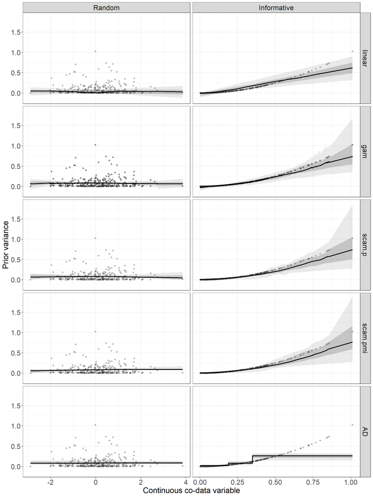

```r
#Figure estimated variance vs continuous co-data for all simulations, fixed G and fixed bam.method----
g <- G[1]
ggplot(dfEst[dfEst$G%in%c(1,2,g,7) & dfEst$Transform==F &
               dfEst$bam.method%in%c("ML","none","splits"),])+# & dfEst$method=="ML",])+
  aes(x=Z)+
  #facet_wrap(Codata~method,scales="free_x",nrow = 2)+
  facet_grid(method~Codata,scales="free_x")+
  geom_point(aes(x=Z,y=truevk),alpha=0.3,col="grey20")+
  geom_ribbon(aes(ymin=q05Vk,ymax=q95Vk),linetype=0,alpha=0.1)+
  geom_ribbon(aes(ymin=q25Vk,ymax=q75Vk),linetype=0,alpha=0.2)+
  geom_line(aes(y=q50Vk),linewidth=1)+ #median
  #geom_line(aes(y=meanVk),size=1)+ #mean
  labs(y="Prior variance",x="Continuous co-data variable")+
  theme_bw()+
  theme(axis.text.x=element_text(size=ts),
        axis.text.y=element_text(size=ts),
        axis.title.x=element_text(size=ts+2),
        axis.title.y=element_text(size=ts+2),
        legend.text=element_text(size=ts),
        legend.title=element_text(size=ts+2),
        strip.text=element_text(size=ts))#,
```

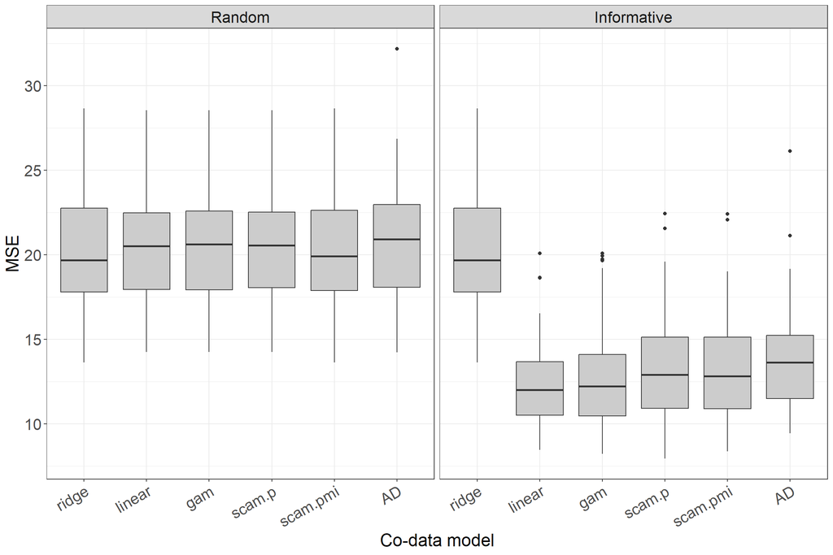

```r
#Figure boxplot prediction performance vs co-data setting for all simulations, fixed G and fixed bam.method----
g <- G[1]
temp <- dfPred[dfPred$G%in%c(1,2) & dfPred$bam.method%in%c("none") &
                 dfPred$method2=="ridge" ,]
temp$method <- "ridge"
temp$G <- factor(1,levels=c(1,2,7,20,50),labels=c(1,2,7,20,50))
temp2 <- dfPred[dfPred$G%in%c(1,2,g,7) & dfPred$bam.method%in%c("none","splits","ML") &
                  dfPred$method2=="ecpc" ,]
temp2$G <- factor(temp2$G,levels=c(1,2,7,20,50),labels=c(1,2,7,20,50))
temp2 <- rbind(temp,temp2)
temp2$method <- factor(temp2$method, levels=unique(temp2$method)[c(1,2,4,5,6,3)],
                       labels=unique(temp2$method)[c(1,2,4,5,6,3)])

ggplot(temp2[temp2$Transform==F,])+#& !(dfPred$Codata=="noninformative"),])+
  aes(x=method,y=MSE)+
  #geom_boxplot(data=temp2[temp2$method=="ridge",],aes(fill=method))+ #ridge prediction performance
  geom_boxplot(fill="grey80")+
  facet_grid(.~Codata2)+
  #coord_cartesian(ylim=c(8,32))+
  #scale_y_log10()+
  labs(y="MSE",x="Co-data model")+
  theme_bw()+
  theme(axis.text.x=element_text(size=ts,angle=30,vjust=1,hjust=1),
        axis.text.y=element_text(size=ts),
        axis.title.x=element_text(size=ts+2),
        axis.title.y=element_text(size=ts+2),
        legend.text=element_text(size=ts),
        legend.title=element_text(size=ts+2),
        strip.text=element_text(size=ts))#,
```

### Estimation and performance for different smoothing penalty estimation methods

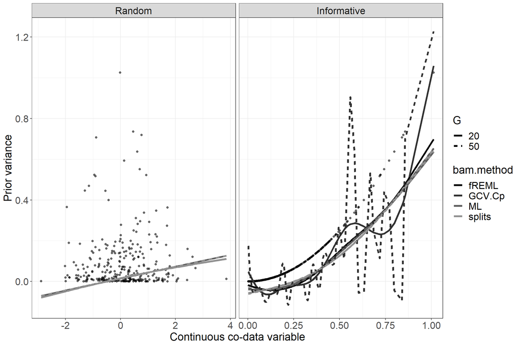

```r
#Figure estimated variance vs continuous co-data for 1 run, different bam.methods----
g <- G[1]
Sim <- 1
ggplot(dfGAMs[dfGAMs$Sim==Sim & dfGAMs$Transform==F & dfGAMs$G%in%c(1,G) ,])+
  aes(x=Z,col=bam.method)+
  facet_grid(.~Codata,scales="free_x")+
  geom_point(aes(x=Z,y=truevk),alpha=0.1,col="black")+
  geom_line(aes(y=vkfit,linetype=G),linewidth=1.5)+
  labs(y="Prior variance",x="Continuous co-data variable")+
  scale_color_manual(values=colsAUC[1:4])+
  theme_bw()+
  theme(axis.text.x=element_text(size=ts),
        axis.text.y=element_text(size=ts),
        axis.title.x=element_text(size=ts+2),
        axis.title.y=element_text(size=ts+2),
        legend.text=element_text(size=ts),
        legend.title=element_text(size=ts+2),
        strip.text=element_text(size=ts))#,
```

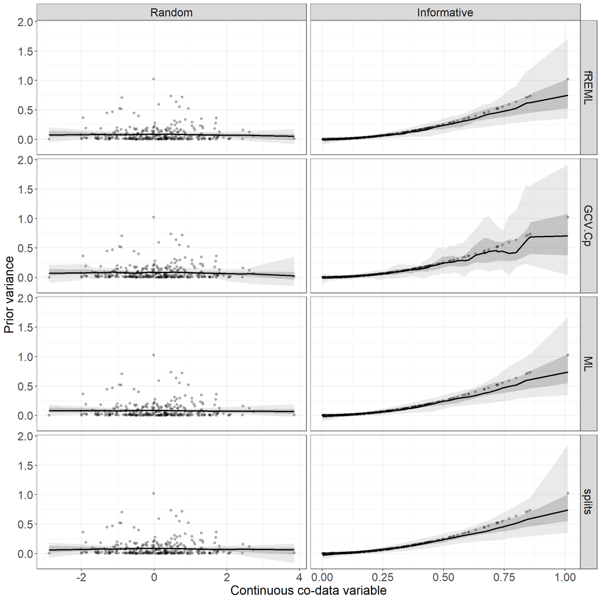

```r
#Figure estimated variance vs continuous co-data for all simulations, gam only, fixed G and different bam.method----
g <- G[1]
ggplot(dfEstGAMs[dfEstGAMs$G%in%c(1,2,g) & dfEstGAMs$Transform==F ,])+
  aes(x=Z)+
  facet_grid(bam.method~Codata,scales="free_x")+
  geom_point(aes(x=Z,y=truevk),alpha=0.3,col="black")+
  geom_ribbon(aes(ymin=q05Vk,ymax=q95Vk),linetype=0,alpha=0.1)+
  geom_ribbon(aes(ymin=q25Vk,ymax=q75Vk),linetype=0,alpha=0.2)+
  geom_line(aes(y=q50Vk),linewidth=1)+ #median
  labs(y="Prior variance",x="Continuous co-data variable")+
  theme_bw()+
  theme(axis.text.x=element_text(size=ts),
        axis.text.y=element_text(size=ts),
        axis.title.x=element_text(size=ts+2),
        axis.title.y=element_text(size=ts+2),
        legend.text=element_text(size=ts),
        legend.title=element_text(size=ts+2),
        strip.text=element_text(size=ts))#,
```

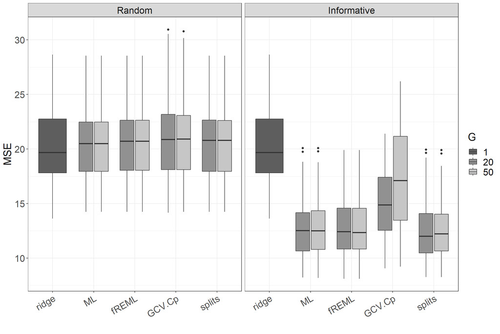

```r
#Figure boxplot prediction performance vs co-data setting for all simulations, gam only, fixed G and different bam.method----
g <- G[1]
temp <- dfPred[dfPred$G%in%c(1,2) & dfPred$bam.method%in%c("none") &
                 dfPred$method2=="ridge" ,]
temp$method <- "ridge"
temp$G <- factor(1,levels=c(1,20,50),labels=c(1,20,50))
temp2 <- dfPredGAMs[dfPredGAMs$G%in%c(G) & dfPredGAMs$method%in%c("gam") &
                      dfPredGAMs$method2=="ecpc" ,]
temp2$G <- factor(temp2$G,levels=c(1,20,50),labels=c(1,20,50))
temp2 <- rbind(temp,temp2)
temp2$bam.method <- factor(temp2$bam.method, levels=unique(temp2$bam.method)[c(1,4,2,3,5)],
                           labels=c("ridge",unique(temp2$bam.method)[c(4,2,3,5)]))

ggplot(temp2[temp2$Transform==F,])+#& !(dfPred$Codata=="noninformative"),])+
  aes(x=bam.method,y=MSE)+
  #geom_boxplot(data=temp2[temp2$method=="ridge",],aes(fill=method))+ #ridge prediction performance
  geom_boxplot(aes(fill=G))+
  facet_grid(.~Codata2)+
  #scale_y_log10()+-
  labs(y="MSE",x="")+
  scale_fill_manual(values=rev(rev(colsAUC)[1:3]))+
  theme_bw()+
  theme(axis.text.x=element_text(size=ts,angle=30,vjust=1,hjust=1),
        axis.text.y=element_text(size=ts),
        axis.title.x=element_text(size=ts+2),
        axis.title.y=element_text(size=ts+2),
        legend.text=element_text(size=ts),
        legend.title=element_text(size=ts+2),
        strip.text=element_text(size=ts))#,
```

### Table computation time

Finally, the table below shows the average run times of the methods. The adaptive discretisation is around 3-6 times as slow as the (constrained) additive co-data models.

```r
#Table average computing times + standard deviation----
timeTable <- dfAll[dfAll$Covariate==1,] %>% group_by(method,bam.method,G) %>%
  summarise(meanTime=mean(Time),sdTime=sd(Time)) %>% ungroup()
print(timeTable)
```

```
#> # A tibble: 14 × 5
#>    method   bam.method G     meanTime sdTime
#>    <fct>    <chr>      <fct>    <dbl>  <dbl>
#>  1 linear   none       2         12.7   4.54
#>  2 gam      fREML      20        12.3   5.57
#>  3 gam      fREML      50        13.0   5.61
#>  4 gam      GCV.Cp     20        11.6   5.49
#>  5 gam      GCV.Cp     50        12.1   5.81
#>  6 gam      ML         20        12.5   5.59
#>  7 gam      ML         50        12.9   5.58
#>  8 gam      splits     20        13.2   5.50
#>  9 gam      splits     50        16.5   5.76
#> 10 scam.p   splits     20        16.5  11.5
#> 11 scam.p   splits     50        19.8  10.6
#> 12 scam.pmi splits     20        20.1  17.6
#> 13 scam.pmi splits     50        26.2  20.4
#> 14 AD       splits     7         72.1   9.77
```

```r
#library("writexl")
#fname <- paste(pathFigures,"TimeTableRaw.xlsx")
#write_xlsx(timeTable,fname)
```

# Simulation study 2: Variable selection compared to other methods

We alter the simulation set-up from above for variable selection. We now set 250 regression coefficients to $0$, leaving 50 non-zero coefficients. We scale the regression coefficients such that the L2-norm of $\mathbf{\beta}^0$ and the scaled, sparse $\mathbf{\beta}^{0,s}$ are the same. We use the following co-data:

1. `Random`: as in the simulation study above, so $Z_k^{(1)}\overset{i.i.d.}{\sim} N(0,1)$ for $k=1,..,p$.
2. `Informative+monotone`: as in the simulation study above, but with white noise added such that the co-data is not exactly $0$ for the zero coefficients, $Z_k^{(2)}\overset{ind.}{\sim} N(|\beta^{0,s}_k|,\sigma_0^2)$, for $\sigma_0$ a tenth of the sample standard deviation of $\mathbf{\beta}^{0,s}$. The effect size $|\beta_k^{0,s}|^2$ is (up till some noise) a monotone, quadratic function of the co-data.
3. `Informative+convex`: similar to the `Informative` co-data but distinguishing negative from positive effects by $Z_k^{(3)}= sign(\beta^{0,s}_k)\cdot Z_k^{(2)}$. The effect size $|\beta_k|^2$ is now (up till some noise) not monotone but a convex, quadratic function of the co-data.

We compare the following variable selection methods:

- `glmnet`: a co-data agnostic elastic net model fitted with glmnet .
- `fwelnet`: an elastic net model with continuous co-data, fitted with fwelnet . The elastic net penalties are a fixed, exponential function of the co-data weights.
- `ecpc+squeezy`: a GAM for the co-data fitted with ecpc, followed by a transformation of the ridge penalties to elastic net penalties by squeezy for variable selection.
- `ecpc+postselection`: a GAM for the co-data, using the default option for posterior selection provided in the ecpc software.

The first three methods have one additional tuning parameter, the elastic net parameter $\alpha\in[0,1]$, with $0$ corresponding to the full model and $1$ to the lasso model. The last method has one tuning parameter, the number of selected covariates (or equivalently, the proportion of estimated zero effects), ranging from 300 to 0 (0 to 1) for the full model to the most sparse model. In practice, one may choose one value from a range of values for the tuning parameter by comparing predictive performances and selecting the sparsest model that performs (nearly) optimal.

## Run analysis

To rerun the analysis and generation of toy data, first set the following variables to `TRUE`:

```r
run_ecpc <- FALSE
run_glmnet <- FALSE
run_fwelnet <- FALSE

generateData <- TRUE #set to true if not generated before
nSim <- 50 #set to lower number for quicker run
runParallel <- FALSE
```

### Load libraries

Load the libraries needed for the analysis. Use multiple cores if available and if `runParallel=TRUE`.

```r
#Load libraries----
library(ecpc)
library(squeezy)
library(glmnet)
```

```r
library(fwelnet)
library(dplyr) #for data wrangling results
library(ggplot2) #for plotting results
library(RColorBrewer) #for plotting results
library(foreach) #for parallel computing
library(doParallel) #for parallel computing
library(mvtnorm)


#optional:
if(runParallel){ #set to 1 to setup parallel backend to use many processors
  cores=detectCores()
  if(!("cl"%in%ls())){
    cl <- makeCluster(cores-1) #not to overload your computer
    registerDoParallel(cl)
  }
}

setting_q <- 1
q <- 5/6 #proportion zeros
maxsel <- c(rep(2:10),10*2:29)
alp_range <- seq(0,1,length.out = length(maxsel))
```

### Generate data

Simulate multiple training and test data sets.

```r
#Simulate toy data ------
p<-300 #number of covariates
n<-100 #sample size training data set
n2<-100 #sample size test data set
sigma <- 1
tauglobal <- 0.1 #prior variance; 0.1, 0.5
model <- "linear"; fam <- "gaussian"
rho <- 0 #correlation in observed X matrix
Sigma <- matrix(rho,p,p); diag(Sigma) <- 1

#simulate all betas i.i.d. from beta_k~N(mean=0,sd=sqrt(0.1)):
set.seed(7474)
Dat <- list()
Dat$beta <- rnorm(p,sd=sqrt(tauglobal))
ind0 <- sample(1:p,floor(q*p),replace=F)
Dat$beta[ind0] <- 0
Dat$beta <- Dat$beta/sqrt(sum(Dat$beta^2))*sqrt(tauglobal*p)
#Dat$Xctd <- matrix(rnorm(n*p) ,n,p)
#Dat$X2ctd <- matrix(rnorm(n2*p) ,n2,p)
Dat$Xctd <- rmvnorm(n,mean=rep(0,p),sigma=Sigma)
Dat$X2ctd <- rmvnorm(n2,mean=rep(0,p),sigma=Sigma)
Dat$lp2 <- Dat$X2ctd%*%Dat$beta
#hist(Dat$lp2)
Dat$Y <- rnorm(n,mean=c(Dat$Xctd%*%Dat$beta),sd=sigma)

#index true, non-zero betas
ind_nonzero <- which(Dat$beta!=0)
ind_zero <- which(Dat$beta==0)

if(generateData){
  AllData <- list()
  for(i in 1:nSim){
    AllData[[i]] <- list()
    AllData[[i]]$beta <- Dat$beta
    if(rho==0){
      AllData[[i]]$Xctd <- matrix(rnorm(n*p) ,n,p)
      AllData[[i]]$X2ctd <- matrix(rnorm(n2*p) ,n2,p)
    }else{
      AllData[[i]]$Xctd <- rmvnorm(n,mean=rep(0,p),sigma=Sigma)
      AllData[[i]]$X2ctd <- rmvnorm(n2,mean=rep(0,p),sigma=Sigma)
    }
    means <- apply(AllData[[i]]$Xctd,2,mean)
    sds <- apply(AllData[[i]]$Xctd,2,sd)

    AllData[[i]]$Y <- rnorm(n,mean=c(AllData[[i]]$Xctd%*%AllData[[i]]$beta),sd=sigma)
    AllData[[i]]$Y2 <- rnorm(n2,mean=c(AllData[[i]]$X2ctd%*%AllData[[i]]$beta),sd=sigma)
  }
  save(Dat,AllData,file=paste(pathResults,"SimDataSparse",setting_q,rho,".Rdata",sep=""))
}else{
  load(paste(pathResults,"SimDataSparse",setting_q,rho,".Rdata",sep=""))
}
```

### Configure co-data

```r
#Co-data settings----
G <- c(20,50) #number of splines
Z.all <- list()
ZI.all <- list() #co-data matrix with intercept
Zs.all <- list()
S1 <- list()
Con.p <- list() #positivity constraints
Con.pmi <- list() #positivity and monotonically increasing constraints
#setting 1: non-informative, unequally spaced
Z.all[["noninformative"]] <- rnorm(p) #for linear co-data model
ZI.all[["noninformative"]] <- cbind(rep(1,p), Z.all[["noninformative"]])
#for generalised additive co-data model:
for(g in 1:length(G)){
  Zs.all[[g]] <- list()
  Zs.all[[g]][["noninformative"]] <- createZforSplines(values=Z.all[["noninformative"]], G=G[g], bdeg=3)
  S1[[g]] <- createS(orderPen=2, G=G[g]) #create 2nd order difference penalty matrix (same for all co-data)

  Con.p[[g]] <- createCon(G=G[g], shape="positive") #create constraints
  Con.pmi[[g]] <- createCon(G=G[g], shape="positive+monotone.i") #create constraints
}
#plot(Z.all[[1]],Dat$beta^2)

#setting 2: informative, unequally spaced, information at edge
set.seed(101010)
Z.all[["size.edge"]] <- abs(Dat$beta)+rnorm(p,sd=sd(Dat$beta)/10)
ZI.all[["size.edge"]] <- cbind(rep(1,p), Z.all[["size.edge"]])
#for generalised additive co-data model:
for(g in 1:length(G)){
  Zs.all[[g]][["size.edge"]] <- createZforSplines(values=Z.all[["size.edge"]], G=G[g], bdeg=3)
}
#plot(Z.all[[2]],Dat$beta^2)

#setting 3: informative, unequally spaced, information at 2 edges
set.seed(101010)
Z.all[["size.edge2"]] <- sign(Dat$beta)*abs(Dat$beta)+rnorm(p,sd=sd(Dat$beta)/10)
ZI.all[["size.edge2"]] <- cbind(rep(1,p), Z.all[["size.edge2"]])
#for generalised additive co-data model:
for(g in 1:length(G)){
  Zs.all[[g]][["size.edge2"]] <- createZforSplines(values=Z.all[["size.edge2"]], G=G[g], bdeg=3)
}
#plot(Z.all[[3]],Dat$beta^2)

#fwelnet
Z_fwelnet <- list(matrix(Z.all[["noninformative"]],nrow = p),
                  matrix(Z.all[["size.edge"]],nrow = p),
                  matrix(Z.all[["size.edge2"]],nrow = p))
```

### ecpc+posterior selection

```r
#Fit ecpc+posterior selection on simulated data sets: generalised additive co-data model----
fname <- paste(pathResults,"SimResAppNoteSparse_GAM",setting_q,rho,".Rdata",sep="")
#fname <- paste(pathResults,"SimResAppNoteGAMSparse_splits",q,rho,".Rdata",sep="") #hypershrinkage=ridge
print(fname)

if(run_ecpc){
  #df <- data.frame()
  #for(sim in 1:nSim){
  finalMatrix <- foreach(sim=1:nSim, .combine=rbind,
                         .packages = c("ecpc", "squeezy")) %dopar% {
                           df <- data.frame()
                           dfSelect <- data.frame()
                           for(setting in 1:3){
                             for(g in 1){
                               for(method in c("ML")){
                                 tic<-proc.time()[[3]]

                                 if(method=="splits"){
                                   fit <- ecpc(Y=AllData[[sim]]$Y,X=AllData[[sim]]$Xctd,
                                               Z=Zs.all[[g]][setting],
                                               paraPen=list(Z1=list(S1=S1[[g]])),
                                               intrcpt.bam = F,
                                               model=model,maxsel=maxsel,
                                               Y2=AllData[[sim]]$Y2,X2=AllData[[sim]]$X2ctd,
                                               hypershrinkage = "ridge",
                                               est_beta_method = "multiridge")
                                 }else{
                                   fit <- ecpc(Y=AllData[[sim]]$Y,X=AllData[[sim]]$Xctd,
                                               Z=Zs.all[[g]][setting],
                                               paraPen=list(Z1=list(S1=S1[[g]])),
                                               bam.method=method,intrcpt.bam = F,
                                               model=model,maxsel=maxsel,
                                               Y2=AllData[[sim]]$Y2,X2=AllData[[sim]]$X2ctd,
                                               est_beta_method = "multiridge")
                                 }


                                 toc <- proc.time()[[3]]-tic

                                 vk <- (Zs.all[[g]][[setting]]%*%fit$gamma )*fit$tauglobal
                                 #plot(Z.all[[setting]],vk)

                                 temp<-data.frame(vkfit=vk,truebeta=Dat$beta,truevk=Dat$beta^2)
                                 temp$Z <- Z.all[[setting]]
                                 temp$Time <- toc
                                 temp$Covariate <- 1:p
                                 temp$G <- G[g]
                                 temp$setting <- setting
                                 temp$bam.method <- method
                                 temp$method <- "gam"
                                 temp$MSEridge <- fit$MSEridge
                                 temp$MSEecpc <- fit$MSEecpc
                                 temp$Sim <- sim
                                 temp$Codata <- names(Z.all)[setting]
                                 temp$Transform <- F; if(setting>=3) temp$Transform <- T
                                 temp$ZUntransformed <- Z.all[[setting]]
                                 temp$q <- q
                                 temp$rho <- rho
                                 if(setting>=3) temp$ZUntransformed <- Z.all[[setting-2]]
                                 df <- rbind(df,temp)

                                 #sensitivity = true positive rate = true positives/total positives
                                 sensitivity <- apply(fit$betaPost,2,function(x){
                                   ind_nonzero_est <- which(x!=0)
                                   TPR <-sum(ind_nonzero_est%in%ind_nonzero)/length(ind_nonzero)
                                   return(TPR)
                                 })
                                 #precision = true negative rate = true negatives/total negatives
                                 precision <- apply(fit$betaPost,2,function(x){
                                   ind_zero_est <- which(x==0)
                                   TNR <-sum(ind_zero_est%in%ind_zero)/length(ind_zero)
                                   return(TNR)
                                 })
                                 lp_train <- AllData[[sim]]$Xctd%*%fit$betaPost
                                 MSEtrain <- apply(lp_train,2,function(lp) mean((lp-AllData[[sim]]$Y)^2))

                                 temp<-data.frame("Tuningparam"=maxsel, sensitivity, precision)
                                 temp$TypeTuning <- "#params"
                                 temp$Time <- toc
                                 temp$G <- G[g]
                                 temp$setting <- setting
                                 temp$bam.method <- method
                                 temp$method <- "gam"
                                 temp$MSEridge <- fit$MSEridge
                                 temp$MSEecpc <- c(fit$MSEPost)
                                 temp$MSEtrain <- c(MSEtrain)
                                 if(is.null(fit$MSEPost)) temp$MSEecpc <- rep(NaN,length(maxsel))
                                 temp$Sim <- sim
                                 temp$Codata <- names(Z.all)[setting]
                                 temp$Transform <- F; if(setting>=3) temp$Transform <- T
                                 temp$q <- q
                                 temp$setting_q <- setting_q
                                 temp$rho <- rho
                                 dfSelect <- rbind(dfSelect, temp)

                                 #fit squeezy
                                 #Use squeezy function to transform estimated ridge penalties to elastic net
                                 #penalties
                                 notinf <- fit$penalties!=Inf
                                 fit.EN <- lapply(alp_range,function(alp){
                                   fit.EN <- squeezy(Y=AllData[[sim]]$Y, X=AllData[[sim]]$Xctd[,notinf],
                                                     groupset=lapply(1:sum(notinf), function(x) x),
                                                     alpha=alp,
                                                     Y2=AllData[[sim]]$Y2,X2=AllData[[sim]]$X2ctd[,notinf],
                                                     lambdas=fit$penalties[notinf],
                                                     sigmasq=fit$sigmahat)})
                                 beta_squeezy <- sapply(1:length(alp_range),function(i){
                                   betas <- rep(0,p)
                                   betas[notinf] <- fit.EN[[i]]$betaApprox
                                   return(betas)
                                 })
                                 MSE_squeezy <- sapply(1:length(alp_range),function(i){
                                   fit.EN[[i]]$MSEApprox
                                 })
                                 lp_train <- AllData[[sim]]$Xctd%*%beta_squeezy
                                 MSEtrain <- apply(lp_train,2,function(lp) mean((lp-AllData[[sim]]$Y)^2))

                                 #sensitivity = true positive rate = true positives/total positives
                                 sensitivity <- apply(beta_squeezy,2,function(x){
                                   ind_nonzero_est <- which(x!=0)
                                   TPR <-sum(ind_nonzero_est%in%ind_nonzero)/length(ind_nonzero)
                                   return(TPR)
                                 })
                                 #precision = true negative rate = true negatives/total negatives
                                 precision <- apply(beta_squeezy,2,function(x){
                                   ind_zero_est <- which(x==0)
                                   TNR <-sum(ind_zero_est%in%ind_zero)/length(ind_zero)
                                   return(TNR)
                                 })

                                 temp<-data.frame("Tuningparam"=alp_range, sensitivity, precision)
                                 temp$TypeTuning <- "alpha"
                                 temp$Time <- toc
                                 temp$G <- G[g]
                                 temp$setting <- setting
                                 temp$bam.method <- method
                                 temp$method <- "gam"
                                 temp$MSEridge <- fit$MSEridge
                                 temp$MSEecpc <- MSE_squeezy
                                 temp$MSEtrain <- c(MSEtrain)
                                 temp$Sim <- sim
                                 temp$Codata <- names(Z.all)[setting]
                                 temp$Transform <- F; if(setting>=3) temp$Transform <- T
                                 temp$q <- q
                                 temp$setting_q <- setting_q
                                 temp$rho <- rho
                                 dfSelect <- rbind(dfSelect,temp)

                               }
                             }
                           }
                           list("df"=df,"dfSelect"=dfSelect)
                         }
  #str(finalMatrix)
  df2 <- lapply(1:nSim,function(i) finalMatrix[i,1][[1]])
  dfSelect2 <- lapply(1:nSim,function(i) finalMatrix[i,2][[1]])
  df <- df2[[1]]; for(i in 2:nSim) df <- rbind(df,df2[[i]])
  dfSelect <- dfSelect2[[1]]; for(i in 2:nSim) dfSelect <- rbind(dfSelect,dfSelect2[[i]])
  save(finalMatrix,df,dfSelect,file=fname)
}
```

### glmnet

```r
#Fit glmnet on simulated data sets----
fname <- paste(pathResults,"SimResAppNoteSparse_glmnet",setting_q,rho,".Rdata",sep="")
#fname <- paste(pathResults,"SimResAppNoteGAMSparse_splits",q,rho,".Rdata",sep="") #hypershrinkage=ridge
print(fname)

if(run_glmnet){
  #df <- data.frame()
  #for(sim in 1:nSim){
  finalMatrix <- foreach(sim=1:nSim, .combine=rbind,
                         .packages = c("glmnet")) %dopar% {
                           dfSelect <- data.frame()
                           for(setting in 1:3){
                             for(alp in alp_range){
                               tic<-proc.time()[[3]]

                               fit.glmnet <- glmnet::cv.glmnet(y=AllData[[sim]]$Y,x=AllData[[sim]]$Xctd,
                                                               family=fam,alpha=alp)
                               beta.glmnet <- coef(fit.glmnet,s="lambda.min", exact=TRUE)
                               Ypred.glmnet <- c(predict(fit.glmnet, newx = AllData[[sim]]$X2ctd,
                                                         s = "lambda.min", type="response", exact=TRUE))
                               MSE.glmnet <- mean((Ypred.glmnet-AllData[[sim]]$Y2)^2)
                               lp_train <- AllData[[sim]]$Xctd%*%beta.glmnet[-1] + beta.glmnet[1]
                               MSEtrain <- mean((lp_train-AllData[[sim]]$Y)^2)
                               toc <- proc.time()[[3]]-tic

                               #sensitivity = true positive rate = true positives/total positives
                               ind_nonzero_est <- which(beta.glmnet[-1]!=0)
                               sensitivity <- sum(ind_nonzero_est%in%ind_nonzero)/length(ind_nonzero)
                               #precision = true negative rate = true negatives/total negatives
                               ind_zero_est <- which(beta.glmnet[-1]==0)
                               precision <- sum(ind_zero_est%in%ind_zero)/length(ind_zero)

                               temp<-data.frame("Tuningparam"=alp, sensitivity, precision)
                               temp$TypeTuning <- "alpha"
                               temp$Time <- toc
                               temp$G <- 1
                               temp$setting <- setting
                               temp$bam.method <- "none"
                               temp$method <- "glmnet"
                               temp$MSEridge <- NaN
                               temp$MSEecpc <- MSE.glmnet
                               temp$MSEtrain <- MSEtrain
                               temp$Sim <- sim
                               temp$Codata <- names(Z.all)[setting]
                               temp$Transform <- F; if(setting>=3) temp$Transform <- T
                               temp$q <- q
                               temp$setting_q <- setting_q
                               temp$rho <- rho
                               dfSelect <- rbind(dfSelect,temp)

                             }
                           }
                           list("dfSelect"=dfSelect)
                         }
  #str(finalMatrix)
  dfSelect <- finalMatrix[[1]]; for(i in 2:nSim) dfSelect <- rbind(dfSelect,finalMatrix[[i]])
  save(finalMatrix,dfSelect,file=fname)
}
```

### fwelnet

```r
#Fit fwelnet on simulated data sets----
fname <- paste(pathResults,"SimResAppNoteSparse_fwelnet",setting_q,rho,".Rdata",sep="")
print(fname)

if(run_fwelnet){
  #df <- data.frame()
  #for(sim in 1:nSim){
  finalMatrix <- foreach(sim=1:nSim, .combine=rbind,
                         .packages = c("fwelnet")) %dopar% {
                           dfSelect <- data.frame()
                           for(setting in 1:3){
                             for(alp in alp_range){
                               tic<-proc.time()[[3]]

                               res.fwEN <-  cv.fwelnet(y=AllData[[sim]]$Y,x=AllData[[sim]]$Xctd,
                                                       z=Z_fwelnet[[setting]],
                                                       alpha=alp,family=fam,standardize=F)

                               ind.minlam <- which(res.fwEN$lambda==res.fwEN$lambda.min)

                               betafwEN <- res.fwEN$glmfit$beta[,ind.minlam]
                               a0fwEN <- res.fwEN$glmfit$a0[ind.minlam]
                               Ypred_fwelnet <- AllData[[sim]]$X2ctd%*%betafwEN+a0fwEN
                               MSE_fwelnet <- mean((Ypred_fwelnet-AllData[[sim]]$Y2)^2)
                               lp_train <- AllData[[sim]]$Xctd%*%betafwEN + a0fwEN
                               MSEtrain <- mean((lp_train-AllData[[sim]]$Y)^2)

                               toc <- proc.time()[[3]]-tic

                               #sensitivity = true positive rate = true positives/total positives
                               ind_nonzero_est <- which(betafwEN!=0)
                               sensitivity <- sum(ind_nonzero_est%in%ind_nonzero)/length(ind_nonzero)
                               #precision = true negative rate = true negatives/total negatives
                               ind_zero_est <- which(betafwEN==0)
                               precision <- sum(ind_zero_est%in%ind_zero)/length(ind_zero)

                               temp<-data.frame("Tuningparam"=alp, sensitivity, precision)
                               temp$TypeTuning <- "alpha"
                               temp$Time <- toc
                               temp$G <- 1
                               temp$setting <- setting
                               temp$bam.method <- "none"
                               temp$method <- "fwelnet"
                               temp$MSEridge <- NaN
                               temp$MSEecpc <- MSE_fwelnet
                               temp$MSEtrain <- c(MSEtrain)
                               temp$Sim <- sim
                               temp$Codata <- names(Z.all)[setting]
                               temp$Transform <- F; if(setting>=3) temp$Transform <- T
                               temp$q <- q
                               temp$setting_q <- setting_q
                               temp$rho <- rho
                               dfSelect <- rbind(dfSelect,temp)

                             }
                           }
                           list("dfSelect"=dfSelect)
                         }
  #str(finalMatrix)
  dfSelect <- finalMatrix[[1]]; for(i in 2:nSim) dfSelect <- rbind(dfSelect,finalMatrix[[i]])
  save(finalMatrix,dfSelect,file=fname)
}
```

## Results

### Load results

First, set some plotting parameters and load the pre-saved results:

```r
#Plots: general parameters----
wdth<-600
hght<-wdth*5/8
wdthpdf <- wdth/75
hghtpdf <- hght/75
ts <- 16 #basis text size in figures
ls <- 1.5 #basis line size in figures
ps <- 2 #basis point size in figures
sz <- 2 #point size
strk <- 1.5 #stroke size
palette <- "Dark2"
#display.brewer.all(10,colorblindFriendly=T)
colpal <- "Dark2"
colsfill <- brewer.pal(3,"Dark2")[1:2]
colsAUC <- brewer.pal(10,"RdYlBu")

#Load data for plots----
#All estimates and predictions
dfAll <- data.frame()
#gam
fname <- paste(pathResults,"SimResAppNoteSparse_GAM",setting_q,rho,".Rdata",sep="")
load(fname)
dfSelect$method[dfSelect$TypeTuning=="#params"] <- "ecpc+postselection"
dfSelect$method[dfSelect$TypeTuning=="alpha"] <- "ecpc+squeezy"
dfAll <- rbind(dfAll,dfSelect)
#glmnet
fname <- paste(pathResults,"SimResAppNoteSparse_glmnet",setting_q,rho,".Rdata",sep="")
load(fname)
dfAll <- rbind(dfAll,dfSelect)

#fwelnet
fname <- paste(pathResults,"SimResAppNoteSparse_fwelnet",setting_q,rho,".Rdata",sep="")
load(fname)
dfAll <- rbind(dfAll,dfSelect)

dfAll$Tuningparam2 <- dfAll$Tuningparam
dfAll$TypeTuning2 <- dfAll$TypeTuning
dfAll$Tuningparam2[dfAll$TypeTuning=="#params"] <- (p-dfAll$Tuningparam2[dfAll$TypeTuning=="#params"])/p
dfAll$TypeTuning2[dfAll$TypeTuning=="#params"] <- "proportion zeros"

dfAll$G <- as.factor(dfAll$G)
dfAll$method <- factor(dfAll$method, levels=unique(dfAll$method)[c(3,4,2,1)],
                       labels=unique(dfAll$method)[c(3,4,2,1)])
dfAll$Codata <- factor(dfAll$Codata,levels=unique(dfAll$Codata),
                       labels=c("Random","Informative+monotone","Informative+convex"))

dfPred <- dfAll %>% group_by(method,Codata,TypeTuning,Tuningparam,TypeTuning2,Tuningparam2) %>%
  summarise(meanMSE=mean(MSEecpc,na.rm=TRUE),method2="EN",
            q50MSE = quantile(MSEecpc,0.5,na.rm=TRUE),
            q95MSE = quantile(MSEecpc,0.95,na.rm=TRUE),q05MSE = quantile(MSEecpc,0.05,na.rm=TRUE),
            q75MSE = quantile(MSEecpc,0.75,na.rm=TRUE),q25MSE = quantile(MSEecpc,0.25,na.rm=TRUE),
            meanMSEtrain=mean(MSEtrain,na.rm=TRUE),method2="EN",
            q50MSEtrain = quantile(MSEtrain,0.5,na.rm=TRUE),
            q95MSEtrain = quantile(MSEtrain,0.95,na.rm=TRUE),q05MSEtrain = quantile(MSEtrain,0.05,na.rm=TRUE),
            q75MSEtrain = quantile(MSEtrain,0.75,na.rm=TRUE),q25MSEtrain = quantile(MSEtrain,0.25,na.rm=TRUE),
            meansensitivity=mean(sensitivity,na.rm=TRUE),
            q50sens = quantile(sensitivity,0.5,na.rm=T),
            q95sens = quantile(sensitivity,0.95,na.rm=T),q05sens = quantile(sensitivity,0.05,na.rm=T),
            q75sens = quantile(sensitivity,0.75,na.rm=T),q25sens = quantile(sensitivity,0.25,na.rm=T),
            meanprecision=mean(precision,na.rm=TRUE),
            q50prec = quantile(precision,0.5,na.rm=T),
            q95prec = quantile(precision,0.95,na.rm=T),q05prec = quantile(precision,0.05,na.rm=T),
            q75prec = quantile(precision,0.75,na.rm=T),q25prec = quantile(precision,0.25,na.rm=T)) %>% ungroup()
```

[output not shown]

### Prediction and variable selection performance

The figures below show the performance of the methods in variable selection and prediction error on the test data. Note that `ecpc+postselection` may be tuned to select sparse models up to a model that is almost empty, reaching a sensitivity and 1-precision of $0$. In contrast, the models selected by the other methods still contain more variables, even in the most sparse models for tuning parameter $\alpha=1$. Besides, `ecpc+squeezy` and `ecpc+postselection` do not always select a full model, explaining why the sensitivities do not reach $1$. This is a result from `ecpc()` truncating estimated negative prior variances to $0$, deselecting some variables a priori. In the sparse setting, the co-data agnostic `glmnet` outperforms the other methods both in terms of variable selection and prediction performance when the co-data is random. This in contrast to the dense simulation setting, in which the prediction performance of `glmnet` and `gam` were on par. For the `informative+monotone` co-data, `fwelnet` slightly outperforms `ecpc+squeezy` and `ecpc+postselection`, all outperforming `glmnet`. For the `informative+convex` co-data, however, `fwelnet` is not able to flexibly adapt to the convex shape of the co-data, while the flexible GAM for the co-data in `ecpc+squeezy` and `ecpc+postselection` still adequately exploits the co-data.

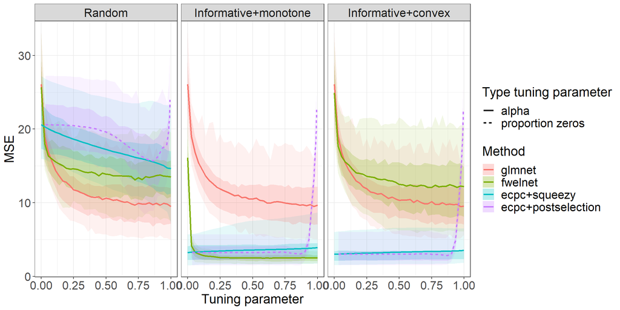

```r
#Figure MSE for all simulations, tuning parameter 2----
ggplot(dfPred)+# & dfEst$method=="ML",])+
  aes(x=Tuningparam2, col=method, fill=method)+
  facet_grid(.~Codata)+
  geom_ribbon(aes(ymin=q05MSE,ymax=q95MSE),linetype=0,alpha=0.1)+
  geom_ribbon(aes(ymin=q25MSE,ymax=q75MSE),linetype=0,alpha=0.2)+
  #geom_line(aes(y=q50MSE, linetype=TypeTuning2),size=1)+ #median
  geom_line(aes(y=meanMSE, linetype=TypeTuning2),size=1)+ #mean
  #scale_y_log10()+
  labs(y="MSE",x="Tuning parameter")+
  guides(fill=guide_legend(title="Method"),
         color=guide_legend(title="Method"),
         linetype=guide_legend(title="Type tuning parameter"))+
  theme_bw()+
  theme(axis.text.x=element_text(size=ts),
        axis.text.y=element_text(size=ts),
        axis.title.x=element_text(size=ts+2),
        axis.title.y=element_text(size=ts+2),
        legend.text=element_text(size=ts),
        legend.title=element_text(size=ts+2),
        strip.text=element_text(size=ts))#,
```

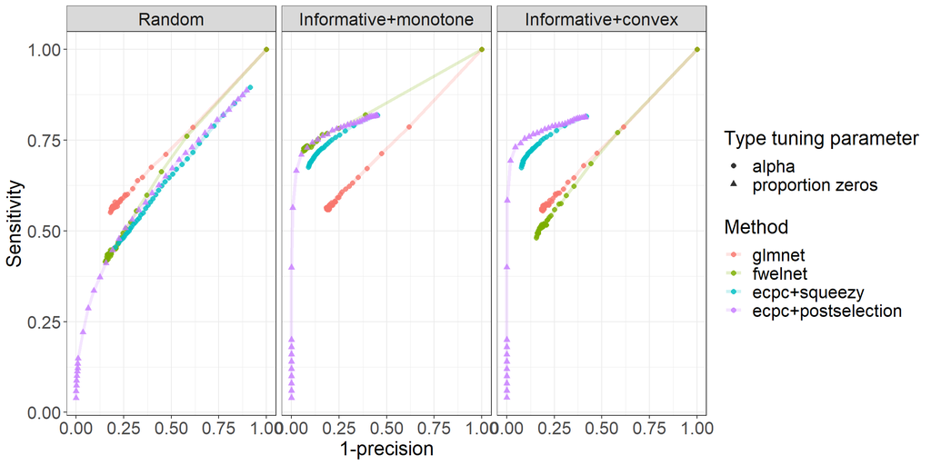

```r
#Figure sensitivity vs precision for all simulations----
ggplot(dfPred)+# & dfEst$method=="ML",])+
  aes(col=method, shape=TypeTuning2)+
  facet_grid(.~Codata)+
  geom_line(aes(y=meansensitivity,x=1-meanprecision),linewidth=ls, alpha=0.2)+ #mean
  geom_point(aes(y=meansensitivity,x=1-meanprecision),size=ps,alpha=0.8)+ #mean
  guides(color=guide_legend(title="Method"),
         shape=guide_legend(title="Type tuning parameter"))+
  #geom_line(aes(y=meanVk),size=1)+ #mean
  labs(y="Sensitivity",x="1-precision")+
  theme_bw()+
  theme(axis.text.x=element_text(size=ts),
        axis.text.y=element_text(size=ts),
        axis.title.x=element_text(size=ts+2),
        axis.title.y=element_text(size=ts+2),
        legend.text=element_text(size=ts),
        legend.title=element_text(size=ts+2),
        strip.text=element_text(size=ts))#,
```

# Simulation study 3: Computation time and memory costs

This section reproduces the figures on computation time and memory costs for a varying number of samples $n$ or number of variables $p$, for the following models:

- ecpc, linear co-data model
- ecpc, generalised additive co-data model (gam)
- ecpc, shape constrained additive co-data model (scam) with positivity constraints
- glmnet, co-data agnostic ridge
- glmnet, co-data agnostic lasso

As co-data, we use one source of the true effect size.

To rerun the analysis and generation of toy data, set the following variables to `TRUE`:

```r
run_n <- FALSE
run_p <- FALSE
generateData <- TRUE
```

## Load libraries

First, load the libraries needed for this simulation study:

```r
#Load libraries-----
library(peakRAM) #for keeping track of time and peak memory
```

```r
library(ecpc)
library(dplyr) #for data wrangling results
library(ggplot2) #for plotting results
library(ggpubr)
library(RColorBrewer) #for plotting results
```

## Generate data

We generate data from a normal distribution for response $Y\in\mathbb{R}^n$, data $X\in\mathbb{R}^{n\times p}$ and regression coefficients $\beta\in\mathbb{R}^p$:
$$\begin{align}
\beta_j \overset{i.i.d.}{\sim} N(0, 0.1),\ j=1,..,p,\\
X_{i,j}\overset{i.i.d.}{\sim} N(0, 1),\ i=1,..,n,\ j=1,..,p,\\
Y_i\overset{ind.}{\sim} N(X_{i,:}\beta, 1), \ i=1,..,n.
\end{align}$$

```r
# Simulate toy data ------
p_all <- c(1000, 2000, 5000, 10000, 20000, 50000, 100000)
n_all <- c(50, 100, 200, 500, 1000)

n2<-100 #sample size test data set
sigma <- 1
tauglobal <- 0.1 #prior variance

#simulate all betas i.i.d. from beta_k~N(mean=0,sd=sqrt(0.1)):
set.seed(5463)
if(generateData){
  AllData_p <- list()
  for(i in 1:length(p_all)){
    p<-p_all[i] #number of covariates
    n<-200 #sample size training data set
    AllData_p[[i]] <- list()
    AllData_p[[i]]$beta <- rnorm(p,sd=sqrt(tauglobal))
    AllData_p[[i]]$Xctd <- matrix(rnorm(n*p) ,n,p)
    AllData_p[[i]]$X2ctd <- matrix(rnorm(n*p) ,n,p)
    AllData_p[[i]]$Y <- rnorm(n,mean=c(AllData_p[[i]]$Xctd%*%AllData_p[[i]]$beta),sd=sigma)
    AllData_p[[i]]$Y2 <- rnorm(n2,mean=c(AllData_p[[i]]$X2ctd%*%AllData_p[[i]]$beta),sd=sigma)
  }
  AllData_n <- list()

  p<-5000 #number of covariates
  betas <- rnorm(p,sd=sqrt(tauglobal))
  for(i in 1:length(n_all)){
    n<-n_all[i] #sample size training data set
    AllData_n[[i]] <- list()
    AllData_n[[i]]$beta <- betas
    AllData_n[[i]]$Xctd <- matrix(rnorm(n*p) ,n,p)
    AllData_n[[i]]$X2ctd <- matrix(rnorm(n*p) ,n,p)
    AllData_n[[i]]$Y <- rnorm(n,mean=c(AllData_n[[i]]$Xctd%*%AllData_n[[i]]$beta),sd=sigma)
    AllData_n[[i]]$Y2 <- rnorm(n2,mean=c(AllData_n[[i]]$X2ctd%*%AllData_n[[i]]$beta),sd=sigma)
  }
  save(AllData_p,AllData_n,file=paste(pathResults,"SimData_p_n.Rdata",sep=''))
}else{
  load(paste(pathResults,"SimData_p_n.Rdata",sep=''))
}
```

## Run analysis for varying n

First, we fit the models for varying number of samples $n$ and for a fixed number of variables $p=5000$.

```r
#Run for p=5000, different n and check time and peak memory----
if(run_n){
  fname <- paste(pathResults, 'res_n.Rdata', sep='')
  df_n = data.frame("Method"=c(), "Time"=c(), "Peak_memory"=c(),
                    "n" = c(), "p"=c())
  p=5000
  #Compute co-data for p=5000
  Z <- abs(AllData_n[[1]]$beta)
  ZI <- cbind(rep(1,p),abs(AllData_n[[1]]$beta))
  Zs <- createZforSplines(values=Z, G=20, bdeg=3)
  S1 <- createS(orderPen=2, G=20) #create 2nd order difference penalty matrix (same for all co-data)
  Con.p <- createCon(G=20, shape="positive")

  for(i in 1:length(n_all)){
    n = n_all[i]

    #ecpc linear co-data model
    mem <- peakRAM({
      fit <- ecpc(Y=AllData_n[[i]]$Y,X=AllData_n[[i]]$Xctd,
                Z=list(ZI),
                model="linear",postselection=FALSE,est_beta_method = "multiridge")
    })
    temp <- data.frame("Method"="ecpc_linear", "Time"=mem[[2]], "Peak_memory"=mem[[4]],
                       "n"=dim(AllData_n[[i]]$Xctd)[1], p=dim(AllData_n[[i]]$Xctd)[2])
    df_n <- rbind(df_n, temp)

    #ecpc GAM co-data model
    mem <- peakRAM({
      fit <- ecpc(Y=AllData_n[[i]]$Y,X=AllData_n[[i]]$Xctd,
                  Z=list(Zs),
                  paraPen=list(Z1=list(S1=S1)),
                  bam.method="ML", intrcpt.bam = F,
                  model="linear",postselection=FALSE,
                  est_beta_method = "multiridge")
    })
    temp <- data.frame("Method"="ecpc_gam", "Time"=mem[[2]], "Peak_memory"=mem[[4]],
                       "n"=dim(AllData_n[[i]]$Xctd)[1], p=dim(AllData_n[[i]]$Xctd)[2])
    df_n <- rbind(df_n, temp)

    #ecpc SCAM co-data model
    mem <- peakRAM({
      fit <- ecpc(Y=AllData_n[[i]]$Y,X=AllData_n[[i]]$Xctd,
                  Z=list(Zs),
                  paraPen=list(Z1=list(S1=S1)),
                  paraCon = list(Z1=Con.p),
                  intrcpt.bam = F,
                  model="linear",postselection = FALSE,
                  est_beta_method = "multiridge")
    })
    temp <- data.frame("Method"="ecpc_scam", "Time"=mem[[2]], "Peak_memory"=mem[[4]],
                       "n"=dim(AllData_n[[i]]$Xctd)[1], p=dim(AllData_n[[i]]$Xctd)[2])
    df_n <- rbind(df_n, temp)

    #glmnet ridge
    mem <- peakRAM({
      fit.glmnet <- glmnet::cv.glmnet(y=AllData_n[[i]]$Y,x=AllData_n[[i]]$Xctd,
                                      family='gaussian',alpha=0)
      beta.glmnet <- coef(fit.glmnet,s="lambda.min", exact=TRUE)
    })
    temp <- data.frame("Method"="glmnet_ridge", "Time"=mem[[2]], "Peak_memory"=mem[[4]],
                       "n"=dim(AllData_n[[i]]$Xctd)[1], p=dim(AllData_n[[i]]$Xctd)[2])
    df_n <- rbind(df_n, temp)


    #glmnet lasso
    mem <- peakRAM({
      fit.glmnet <- glmnet::cv.glmnet(y=AllData_n[[i]]$Y,x=AllData_n[[i]]$Xctd,
                                      family='gaussian',alpha=1)
      beta.glmnet <- coef(fit.glmnet,s="lambda.min", exact=TRUE)
    })
    temp <- data.frame("Method"="glmnet_lasso", "Time"=mem[[2]], "Peak_memory"=mem[[4]],
                       "n"=dim(AllData_n[[i]]$Xctd)[1], p=dim(AllData_n[[i]]$Xctd)[2])
    df_n <- rbind(df_n, temp)

    save(df_n, file=fname)
  }

}
```

## Run analysis for varying p

Then, we fit the models for varying number of samples $p$ and for a fixed number of samples $n=200$.

```r
#Run for n=200, different p and check time and peak memory----
if(run_p){
  fname <- paste(pathResults, 'res_p.Rdata', sep='')
  df_p = data.frame("Method"=c(), "Time"=c(), "Peak_memory"=c(),
                    "n" = c(), "p"=c())

  for(i in 1:length(p_all)){
    p = p_all[i]

    #Compute co-data for p
    Z <- abs(AllData_p[[i]]$beta)
    ZI <- cbind(rep(1,p),abs(AllData_p[[1]]$beta))
    Zs <- createZforSplines(values=Z, G=20, bdeg=3)
    S1 <- createS(orderPen=2, G=20) #create 2nd order difference penalty matrix (same for all co-data)
    Con.p <- createCon(G=20, shape="positive")

    #ecpc linear co-data model
    mem <- peakRAM({
      fit <- ecpc(Y=AllData_p[[i]]$Y,X=AllData_p[[i]]$Xctd,
                  Z=list(ZI),
                  model="linear",postselection=FALSE,est_beta_method = "multiridge")
    })
    temp <- data.frame("Method"="ecpc_linear", "Time"=mem[[2]], "Peak_memory"=mem[[4]],
                       "n"=dim(AllData_p[[i]]$Xctd)[1], p=dim(AllData_p[[i]]$Xctd)[2])
    df_p <- rbind(df_p, temp)

    #ecpc GAM co-data model
    mem <- peakRAM({
      fit <- ecpc(Y=AllData_p[[i]]$Y,X=AllData_p[[i]]$Xctd,
                  Z=list(Zs),
                  paraPen=list(Z1=list(S1=S1)),
                  bam.method="ML", intrcpt.bam = F,
                  model="linear",postselection=FALSE,
                  est_beta_method = "multiridge")
    })
    temp <- data.frame("Method"="ecpc_gam", "Time"=mem[[2]], "Peak_memory"=mem[[4]],
                       "n"=dim(AllData_p[[i]]$Xctd)[1], p=dim(AllData_p[[i]]$Xctd)[2])
    df_p <- rbind(df_p, temp)

    #ecpc SCAM co-data model
    mem <- peakRAM({
      fit <- ecpc(Y=AllData_p[[i]]$Y,X=AllData_p[[i]]$Xctd,
                  Z=list(Zs),
                  paraPen=list(Z1=list(S1=S1)),
                  paraCon = list(Z1=Con.p),
                  intrcpt.bam = F,
                  model="linear",postselection = FALSE,
                  est_beta_method = "multiridge")
    })
    temp <- data.frame("Method"="ecpc_scam", "Time"=mem[[2]], "Peak_memory"=mem[[4]],
                       "n"=dim(AllData_p[[i]]$Xctd)[1], p=dim(AllData_p[[i]]$Xctd)[2])
    df_p <- rbind(df_p, temp)

    #glmnet ridge
    mem <- peakRAM({
      fit.glmnet <- glmnet::cv.glmnet(y=AllData_p[[i]]$Y,x=AllData_p[[i]]$Xctd,
                                      family='gaussian',alpha=0)
      beta.glmnet <- coef(fit.glmnet,s="lambda.min", exact=TRUE)
    })
    temp <- data.frame("Method"="glmnet_ridge", "Time"=mem[[2]], "Peak_memory"=mem[[4]],
                       "n"=dim(AllData_p[[i]]$Xctd)[1], p=dim(AllData_p[[i]]$Xctd)[2])
    df_p <- rbind(df_p, temp)


    #glmnet lasso
    mem <- peakRAM({
      fit.glmnet <- glmnet::cv.glmnet(y=AllData_p[[i]]$Y,x=AllData_p[[i]]$Xctd,
                                      family='gaussian',alpha=1)
      beta.glmnet <- coef(fit.glmnet,s="lambda.min", exact=TRUE)
    })
    temp <- data.frame("Method"="glmnet_lasso", "Time"=mem[[2]], "Peak_memory"=mem[[4]],
                       "n"=dim(AllData_p[[i]]$Xctd)[1], p=dim(AllData_p[[i]]$Xctd)[2])
    df_p <- rbind(df_p, temp)

    save(df_p, file=fname)
  }

}
```

## Plot results

### Plot parameters

First, set some general parameters for plotting:

```r
#Plots: general parameters----
wdth<-600
hght<-wdth*5/8
wdthpdf <- wdth/75
hghtpdf <- hght/75
ts <- 16 #basis text size in figures
ls <- 1.5 #basis line size in figures
ps <- 2 #basis point size in figures
sz <- 2 #point size
strk <- 1.5 #stroke size
```

### Load results for plotting

Load the pre-saved results with:

```r
#Load data for plots----
#different n, p=5000 fixed
fname <- paste(pathResults, 'res_n.Rdata', sep='')
load(fname)
df_n$Method <- factor(df_n$Method,levels=unique(df_n$Method),
                        labels=unique(df_n$Method))

#different p, n=200 fixed
fname <- paste(pathResults, 'res_p.Rdata', sep='')
load(fname)
df_p$Method <- factor(df_p$Method,levels=unique(df_p$Method),
                      labels=unique(df_p$Method))
```

### Figure time vs n

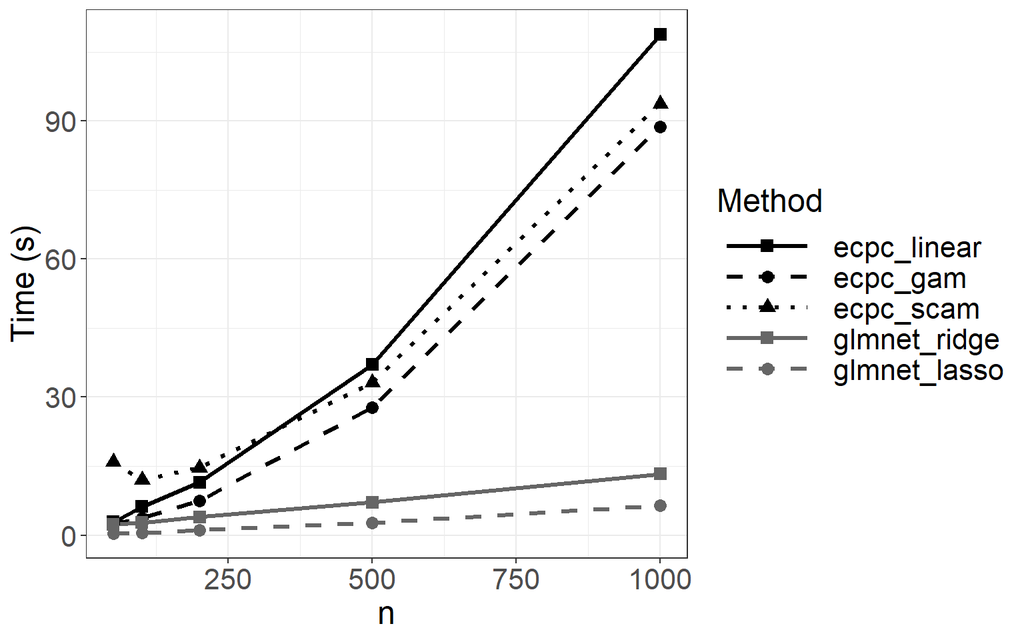

```r
p1 <- ggplot(df_n)+
  aes(x=n,y=Time,col=Method,linetype=Method,shape=Method)+
  geom_line(linewidth=1.2)+
  geom_point(size=ps*1.5)+
  scale_color_manual(values=c('black','black','black','grey40','grey40'))+
  scale_linetype_manual(values=c(1,2,3,1,2))+
  scale_shape_manual(values=c(15,16,17,15,16))+
  #scale_y_log10()+
  labs(y="Time (s)",x="n")+
  theme_bw()+
  theme(axis.text.x=element_text(size=ts),
        axis.text.y=element_text(size=ts),
        axis.title.x=element_text(size=ts+2),
        axis.title.y=element_text(size=ts+2),
        legend.text=element_text(size=ts),
        legend.title=element_text(size=ts+2),
        strip.text=element_text(size=ts),
        legend.key.width = unit(2, "cm"))#,
p1
```

### Figure memory vs n

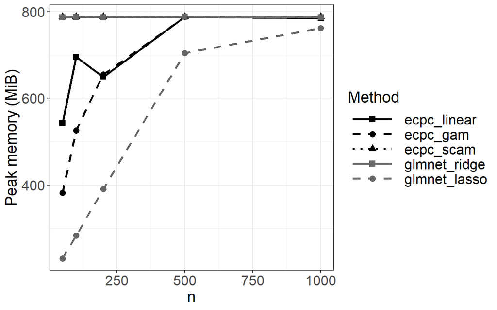

```r
p2 <- ggplot(df_n)+
  aes(x=n,y=Peak_memory,col=Method,linetype=Method,shape=Method)+
  geom_line(linewidth=1.2)+
  geom_point(size=ps*1.5)+
  scale_color_manual(values=c('black','black','black','grey40','grey40'))+
  scale_linetype_manual(values=c(1,2,3,1,2))+
  scale_shape_manual(values=c(15,16,17,15,16))+
  #scale_y_log10()+
  labs(y="Peak memory (MiB)",x="n")+
  theme_bw()+
  theme(axis.text.x=element_text(size=ts),
        axis.text.y=element_text(size=ts),
        axis.title.x=element_text(size=ts+2),
        axis.title.y=element_text(size=ts+2),
        legend.text=element_text(size=ts),
        legend.title=element_text(size=ts+2),
        strip.text=element_text(size=ts),
        legend.key.width = unit(2, "cm"))#,
p2
```

### Figure time vs p

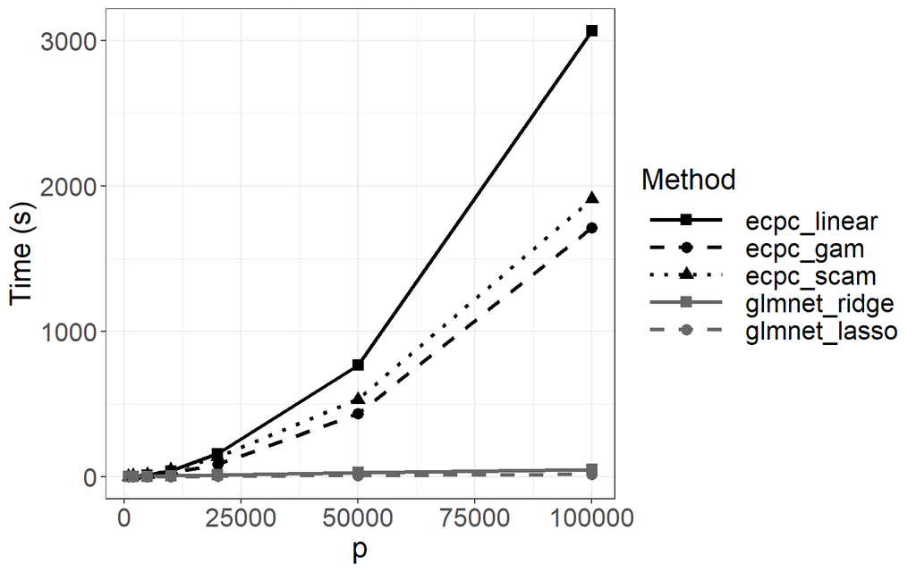

```r
p3 <- ggplot(df_p)+
  aes(x=p,y=Time,col=Method,linetype=Method,shape=Method)+
  geom_line(linewidth=1.2)+
  geom_point(size=ps*1.5)+
  scale_color_manual(values=c('black','black','black','grey40','grey40'))+
  scale_linetype_manual(values=c(1,2,3,1,2))+
  scale_shape_manual(values=c(15,16,17,15,16))+
  #scale_y_log10()+
  labs(y="Time (s)",x="p")+
  theme_bw()+
  theme(axis.text.x=element_text(size=ts),
        axis.text.y=element_text(size=ts),
        axis.title.x=element_text(size=ts+2),
        axis.title.y=element_text(size=ts+2),
        legend.text=element_text(size=ts),
        legend.title=element_text(size=ts+2),
        strip.text=element_text(size=ts),
        legend.key.width = unit(2, "cm"))#,
p3
```

### Figure memory vs p

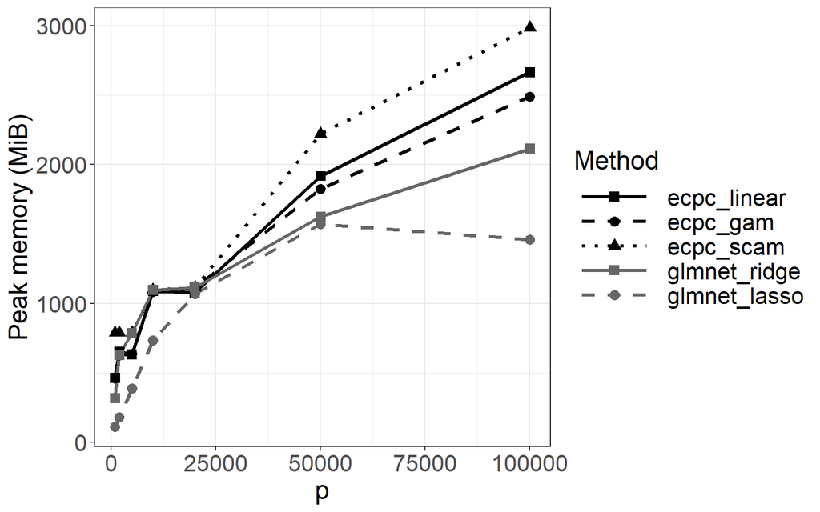

```r
p4 <- ggplot(df_p)+
  aes(x=p,y=Peak_memory,col=Method,linetype=Method,shape=Method)+
  geom_line(linewidth=1.2)+
  geom_point(size=ps*1.5)+
  scale_color_manual(values=c('black','black','black','grey40','grey40'))+
  scale_linetype_manual(values=c(1,2,3,1,2))+
  scale_shape_manual(values=c(15,16,17,15,16))+
  #scale_y_log10()+
  labs(y="Peak memory (MiB)",x="p")+
  theme_bw()+
  theme(axis.text.x=element_text(size=ts),
        axis.text.y=element_text(size=ts),
        axis.title.x=element_text(size=ts+2),
        axis.title.y=element_text(size=ts+2),
        legend.text=element_text(size=ts),
        legend.title=element_text(size=ts+2),
        strip.text=element_text(size=ts),
        legend.key.width = unit(2, "cm"))#,
p4
```

### Combine plots

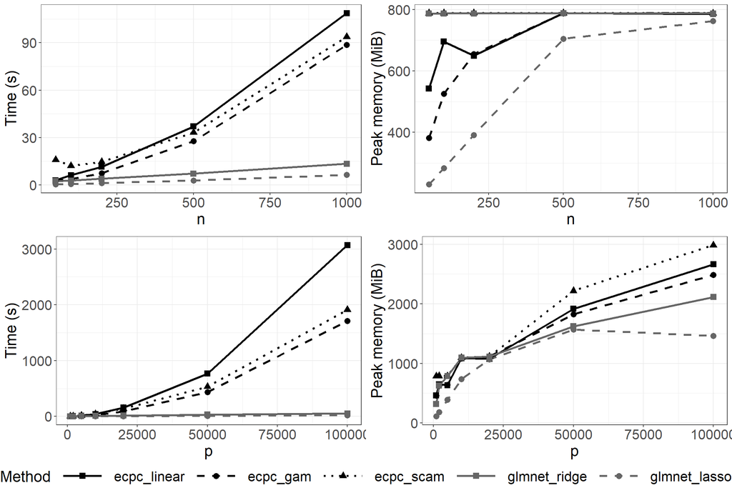

```r
p <- ggarrange(
  p1, p2, p3, p4,
  common.legend = TRUE, legend = "bottom"
)
p
```

# References

[1] van Nee, M.M., Wessels, L.F.A., van de Wiel, M.A.: ecpc: an R-package for generic co-data models for high-dimensional prediction

[2] van Nee, M.M., Wessels, L.F.A., van de Wiel, M.A.: Flexible co-data learning for high-dimensional prediction. Statistics in Medicine 40(26), 5910–5925 (2021)

[3] Eilers, P.H., Marx, B.D.: Practical Smoothing: The Joys of P-splines. Cambridge University Press, Cambridge (2021)